# Ceteris Paribus explenations for white wine quality dataset

#### Sweet Wine

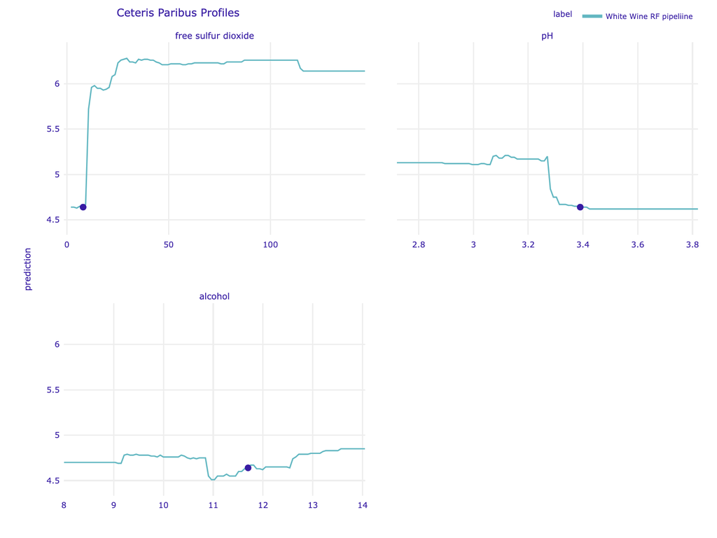

Sweet wine seemed to be (in the model's eyes) wight below the free sulfur dioxide value that is considered to belong to average-good wine. Changing it just a little bit would acctually result in a near-perfect prediction.

Against expectation and comparison to the strong wine, alcohol in case of the sweet wine has close-to-none influence.

To further point out locallity of the explanations, the influence of pH is exactly opposite for strong and sweet wine

#### Best wine

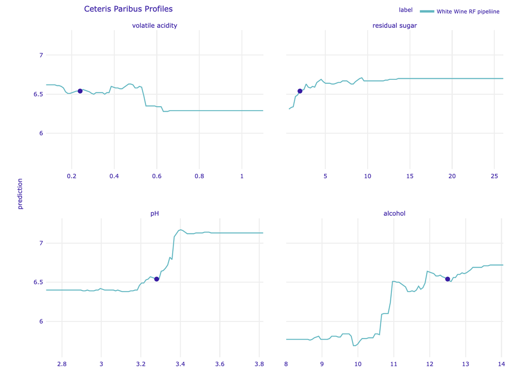

Quite opposite to the sweet wine response, the best wine seems to have very similiar explanations to the strong wine. Those can occure, proving it is important to check for quite a few explanations before assuming close-to-global dependencies.

## Inter model comparisions

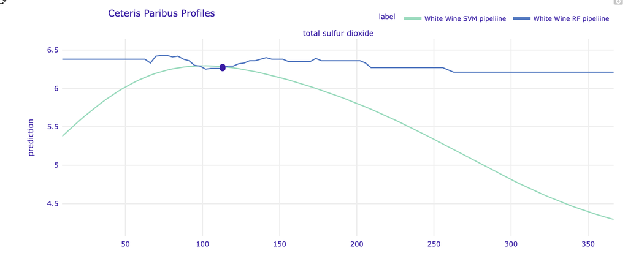

By the nature of the regressor, every profile of SVR was much smoother than that of RF. Having said that in most cases the shape of the line was quite similiar, with slight changes in y-shift. The most standing out difference was this of the total sulfur dioxide in the strong wine. While RF profile was quite linear, with slight dent around the actual value, the SVR profile was a curve, with the highest point nearny the actual value.

This is especially interesting given that both models made very close score-wise predictions, but the explanations are quite different.

This proves that ceteris paribus profile shouldn't be used to conclude dependencies as real-world factual, but rather should only be used to describe specific model.

# Appendix

## Packages

```python
!pip install dalex
```

[output not shown]

```python
import pandas as pd
from sklearn.ensemble import RandomForestRegressor
from sklearn.linear_model import LogisticRegression
from sklearn.svm import SVR
from sklearn.metrics import mean_squared_error
from sklearn.model_selection import train_test_split
import numpy as np
import dalex as dx
```

## Getting the data

```python
!wget https://archive.ics.uci.edu/ml/machine-learning-databases/wine-quality/winequality-white.csv
```

```
--2022-04-21 17:53:04--  https://archive.ics.uci.edu/ml/machine-learning-databases/wine-quality/winequality-white.csv
Resolving archive.ics.uci.edu (archive.ics.uci.edu)... 128.195.10.252
Connecting to archive.ics.uci.edu (archive.ics.uci.edu)|128.195.10.252|:443... connected.
HTTP request sent, awaiting response... 200 OK
Length: 264426 (258K) [application/x-httpd-php]
Saving to: ‘winequality-white.csv.1’

winequality-white.c 100%[===================>] 258.23K   937KB/s    in 0.3s

2022-04-21 17:53:05 (937 KB/s) - ‘winequality-white.csv.1’ saved [264426/264426]
```

```python
X = pd.read_csv('/content/winequality-white.csv', sep=';')
Y = pd.DataFrame(X.iloc[:,-1])
X = X.iloc[:,:-1]
```

## Selecting instances for local model decompositions (with predictions)

### Strong wine

```python
X.sort_values('alcohol').tail(1)
```

|  | fixed acidity | volatile acidity | citric acid | residual sugar | chlorides | free sulfur dioxide | total sulfur dioxide | density | pH | sulphates | alcohol |
| --- | --- | --- | --- | --- | --- | --- | --- | --- | --- | --- | --- |
| 3918 | 6.4 | 0.35 | 0.28 | 1.6 | 0.037 | 31.0 | 113.0 | 0.98779 | 3.12 | 0.4 | 14.2 |

```python
strong_wine_id = X.sort_values('alcohol').tail(1).index[0]
strong_wine = X.iloc[strong_wine_id]
strong_wine_y = Y.iloc[strong_wine_id]
```

### Sweet wine

```python
X.sort_values('residual sugar').tail(1)
```

|  | fixed acidity | volatile acidity | citric acid | residual sugar | chlorides | free sulfur dioxide | total sulfur dioxide | density | pH | sulphates | alcohol |
| --- | --- | --- | --- | --- | --- | --- | --- | --- | --- | --- | --- |
| 2781 | 7.8 | 0.965 | 0.6 | 65.8 | 0.074 | 8.0 | 160.0 | 1.03898 | 3.39 | 0.69 | 11.7 |

```python
sweet_wine_id = X.sort_values('residual sugar').tail(1).index[0]
sweet_wine = X.iloc[sweet_wine_id]
sweet_wine_y = Y.iloc[sweet_wine_id]
```

### Best wine

```python
best_wine_id=np.where(Y['quality'].values==max(Y.values))[0][2]
```

```python
best_wine = X.iloc[best_wine_id]
best_wine_y = Y.iloc[best_wine_id]
```